# Pattern-Based Security Enhancement for AI-Generated Code: Statistical Analysis

AST-Guided Chain-of-Thought Prompting vs. Natural Language Prompting

Endry Alberto Melo

December 09, 2025

# 1 Data Loading

```r
# Load and combine all iteration files
files <- paste0("experiment_results_iteration_", 1:5, ".csv")
df <- do.call(rbind, lapply(files, read.csv, stringsAsFactors = FALSE))

# Preprocessing
df$condition <- factor(df$condition,
                       levels = c("AST_COT", "NL_COT"),
                       labels = c("AST-Guided CoT", "Natural Language CoT"))
df$model <- factor(df$model, levels = c("CLAUDE", "GPT4"), labels = c("Claude", "GPT-4"))

# Primary metric: Does sample have at least one vulnerability?
df$has_vulnerability <- df$num_vulnerabilities > 0
```

```r
data_info <- data.frame(
  Metric = c("Total Samples", "Prompting Methods", "LLM Models"),
  Value = c(nrow(df), "AST-Guided CoT, Natural Language CoT", "Claude, GPT-4")
)
knitr::kable(data_info, caption = "Dataset Overview", row.names = FALSE)
```

Dataset Overview

| Metric | Value |
| --- | --- |
| Total Samples | 500 |
| Prompting Methods | AST-Guided CoT, Natural Language CoT |
| LLM Models | Claude, GPT-4 |

# 2 Analysis 1: Descriptive Statistics

## 2.1 Total Vulnerability Count (Primary Metric)

Total vulnerability count measures the total number of security vulnerabilities detected across all code samples for each prompting method.

```r
# Total vulnerabilities by treatment group
vuln_by_group <- aggregate(num_vulnerabilities ~ condition + model, data = df, FUN = sum)
vuln_wide <- reshape(vuln_by_group, idvar = "condition", timevar = "model", direction = "wide")
names(vuln_wide) <- c("Prompting Method", "Claude", "GPT-4")
vuln_wide$Total <- vuln_wide$Claude + vuln_wide$`GPT-4`

knitr::kable(vuln_wide,
             caption = "Table 1: Total Vulnerability Count by Treatment Group",
             row.names = FALSE)
```

Table 1: Total Vulnerability Count by Treatment Group

| Prompting Method | Claude | GPT-4 | Total |
| --- | --- | --- | --- |
| AST-Guided CoT | 25 | 23 | 48 |
| Natural Language CoT | 40 | 45 | 85 |

```r
# By prompting method only
vuln_totals <- aggregate(num_vulnerabilities ~ condition, data = df, FUN = sum)
names(vuln_totals) <- c("Prompting Method", "Total Vulnerabilities")

# Add sample counts
sample_counts <- aggregate(sample_id ~ condition, data = df, FUN = length)
vuln_totals$`Total Samples` <- sample_counts$sample_id
vuln_totals$`Mean per Sample` <- round(vuln_totals$`Total Vulnerabilities` / vuln_totals$`Total Samples`, 3)

knitr::kable(vuln_totals,
             caption = "Table 2: Total Vulnerabilities by Prompting Method",
             row.names = FALSE)
```

Table 2: Total Vulnerabilities by Prompting Method

| Prompting Method | Total Vulnerabilities | Total Samples | Mean per Sample |
| --- | --- | --- | --- |
| AST-Guided CoT | 48 | 250 | 0.192 |
| Natural Language CoT | 85 | 250 | 0.340 |

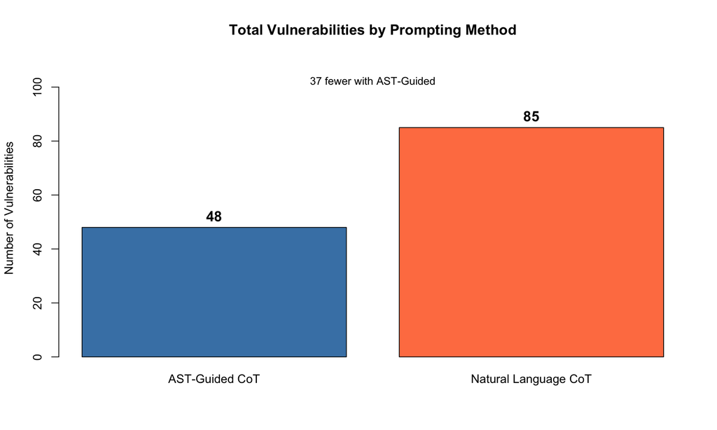

Figure 1: Total Vulnerabilities by Prompting Method

```r
totals <- c(
  sum(df$num_vulnerabilities[df$condition == "AST-Guided CoT"]),
  sum(df$num_vulnerabilities[df$condition == "Natural Language CoT"])
)
names(totals) <- c("AST-Guided CoT", "Natural Language CoT")

bp <- barplot(totals, col = c("steelblue", "coral"),
        main = "Total Vulnerabilities by Prompting Method",
        ylab = "Number of Vulnerabilities",
        ylim = c(0, max(totals) * 1.3))
text(x = bp, y = totals + max(totals) * 0.05, labels = totals, font = 2, cex = 1.2)

# Add difference annotation
if (totals[1] < totals[2]) {
  diff_text <- paste0(totals[2] - totals[1], " fewer with AST-Guided")
} else {
  diff_text <- paste0(totals[1] - totals[2], " fewer with NL CoT")
}
mtext(diff_text, side = 3, line = -2, cex = 0.9)
```

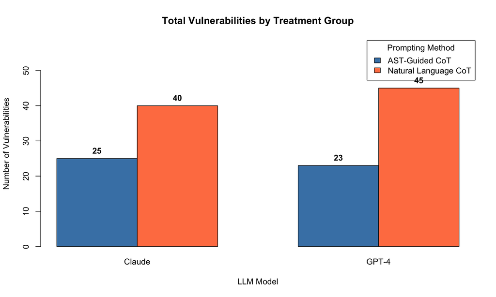

Figure 2: Total Vulnerabilities by Treatment Group

```r
count_matrix <- matrix(
  c(
    sum(df$num_vulnerabilities[df$condition == "AST-Guided CoT" & df$model == "Claude"]),
    sum(df$num_vulnerabilities[df$condition == "Natural Language CoT" & df$model == "Claude"]),
    sum(df$num_vulnerabilities[df$condition == "AST-Guided CoT" & df$model == "GPT-4"]),
    sum(df$num_vulnerabilities[df$condition == "Natural Language CoT" & df$model == "GPT-4"])
  ),
  nrow = 2, ncol = 2, byrow = FALSE
)
rownames(count_matrix) <- c("AST-Guided CoT", "Natural Language CoT")
colnames(count_matrix) <- c("Claude", "GPT-4")

bar_pos <- barplot(count_matrix,
        beside = TRUE,
        col = c("steelblue", "coral"),
        main = "Total Vulnerabilities by Treatment Group",
        xlab = "LLM Model",
        ylab = "Number of Vulnerabilities",
        ylim = c(0, max(count_matrix) * 1.3),
        legend.text = rownames(count_matrix),
        args.legend = list(x = "topright", title = "Prompting Method"))

text(x = bar_pos, y = count_matrix + max(count_matrix) * 0.05, labels = count_matrix, font = 2)
```

## 2.2 Vulnerability Rate (Secondary Metric)

Vulnerability rate measures the percentage of code samples that contain at least one security vulnerability.

```r
# Calculate vulnerability rate by treatment group
vuln_rate <- aggregate(has_vulnerability ~ condition + model, data = df,
                       FUN = function(x) round(mean(x) * 100, 1))
names(vuln_rate) <- c("Prompting Method", "Model", "Vulnerability Rate (%)")

# Pivot for display
rate_wide <- reshape(vuln_rate, idvar = "Prompting Method", timevar = "Model", direction = "wide")
names(rate_wide) <- gsub("Vulnerability Rate \\(%\\)\\.", "", names(rate_wide))

knitr::kable(rate_wide,
             caption = "Table 3: Vulnerability Rate by Treatment Group (% of Samples with ≥1 Vulnerability)",
             row.names = FALSE)
```

Table 3: Vulnerability Rate by Treatment Group (% of Samples with ≥1 Vulnerability)

| Prompting Method | Claude | GPT-4 |
| --- | --- | --- |
| AST-Guided CoT | 12.0 | 12.8 |
| Natural Language CoT | 21.6 | 22.4 |

```r
# Overall by prompting method
condition_rate <- aggregate(has_vulnerability ~ condition, data = df,
                            FUN = function(x) c(
                              Rate = round(mean(x) * 100, 1),
                              Vulnerable = sum(x),
                              Total = length(x)
                            ))
condition_rate <- do.call(data.frame, condition_rate)
names(condition_rate) <- c("Prompting Method", "Vulnerability Rate (%)", "Samples with Vulnerabilities", "Total Samples")

knitr::kable(condition_rate,
             caption = "Table 4: Vulnerability Rate by Prompting Method",
             row.names = FALSE)
```

Table 4: Vulnerability Rate by Prompting Method

| Prompting Method | Vulnerability Rate (%) | Samples with Vulnerabilities | Total Samples |
| --- | --- | --- | --- |
| AST-Guided CoT | 12.4 | 31 | 250 |
| Natural Language CoT | 22.0 | 55 | 250 |

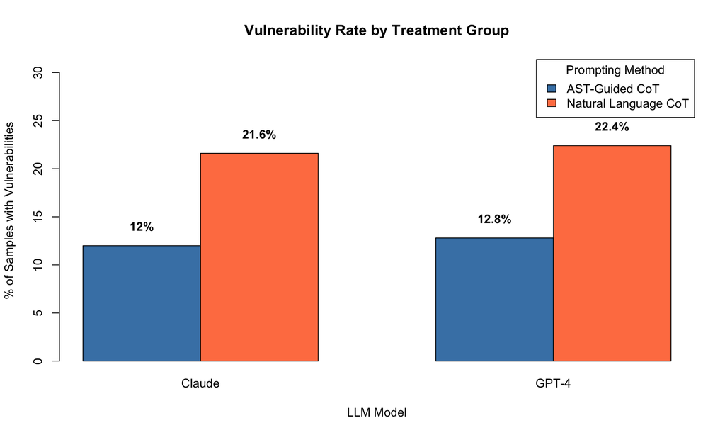

Figure 3: Vulnerability Rate by Treatment Group

```r
# Create data for plot
rate_matrix <- matrix(
  c(
    mean(df$has_vulnerability[df$condition == "AST-Guided CoT" & df$model == "Claude"]) * 100,
    mean(df$has_vulnerability[df$condition == "Natural Language CoT" & df$model == "Claude"]) * 100,
    mean(df$has_vulnerability[df$condition == "AST-Guided CoT" & df$model == "GPT-4"]) * 100,
    mean(df$has_vulnerability[df$condition == "Natural Language CoT" & df$model == "GPT-4"]) * 100
  ),
  nrow = 2, ncol = 2, byrow = FALSE
)
rownames(rate_matrix) <- c("AST-Guided CoT", "Natural Language CoT")
colnames(rate_matrix) <- c("Claude", "GPT-4")

bar_pos <- barplot(rate_matrix,
        beside = TRUE,
        col = c("steelblue", "coral"),
        main = "Vulnerability Rate by Treatment Group",
        xlab = "LLM Model",
        ylab = "% of Samples with Vulnerabilities",
        ylim = c(0, max(rate_matrix) * 1.4),
        legend.text = rownames(rate_matrix),
        args.legend = list(x = "topright", title = "Prompting Method"))

text(x = bar_pos, y = rate_matrix + 2, labels = paste0(round(rate_matrix, 1), "%"), font = 2)
```

# 3 Analysis 2: Chi-Square Test

The Chi-Square test determines if there is a statistically significant relationship between prompting method and vulnerability occurrence.

**Null Hypothesis (H₀):** There is no relationship between prompting method and vulnerability rate.

**Alternative Hypothesis (H₁):** There is a relationship between prompting method and vulnerability rate.

```r
# Create contingency table
contingency <- table(df$condition, df$has_vulnerability)
colnames(contingency) <- c("No Vulnerability", "Has Vulnerability")

knitr::kable(contingency,
             caption = "Table 4: Contingency Table - Prompting Method × Vulnerability Status")
```

Table 4: Contingency Table - Prompting Method × Vulnerability Status

|  | No Vulnerability | Has Vulnerability |
| --- | --- | --- |
| AST-Guided CoT | 219 | 31 |
| Natural Language CoT | 195 | 55 |

```r
# Chi-square test
chi_test <- chisq.test(contingency)

chi_results <- data.frame(
  Statistic = "Chi-Square (χ²)",
  Value = round(chi_test$statistic, 3),
  `Degrees of Freedom` = chi_test$parameter,
  `p-value` = round(chi_test$p.value, 4),
  `Significant (α = .05)` = ifelse(chi_test$p.value < 0.05, "Yes", "No")
)

knitr::kable(chi_results,
             caption = "Table 5: Chi-Square Test Results",
             row.names = FALSE)
```

Table 5: Chi-Square Test Results

| Statistic | Value | Degrees.of.Freedom | p.value | Significant..α….05. |
| --- | --- | --- | --- | --- |
| Chi-Square (χ²) | 7.429 | 1 | 0.0064 | Yes |

```r
if (chi_test$p.value < 0.05) {
  cat("**Interpretation:** The p-value is less than 0.05, so we reject the null hypothesis. There IS a statistically significant relationship between prompting method and vulnerability rate.")
} else {
  cat("**Interpretation:** The p-value is greater than 0.05, so we fail to reject the null hypothesis. There is NO statistically significant relationship between prompting method and vulnerability rate. The observed difference may be due to chance.")
}
```

**Interpretation:** The p-value is less than 0.05, so we reject the null hypothesis. There IS a statistically significant relationship between prompting method and vulnerability rate.

# 4 Analysis 3: Independent Samples T-Test

The t-test compares the mean number of vulnerabilities per sample between the two prompting methods.

**Null Hypothesis (H₀):** There is no difference in mean vulnerability count between prompting methods.

**Alternative Hypothesis (H₁):** There is a difference in mean vulnerability count between prompting methods.

```r
# Get vulnerability counts for each group
ast_vulns <- df$num_vulnerabilities[df$condition == "AST-Guided CoT"]
nl_vulns <- df$num_vulnerabilities[df$condition == "Natural Language CoT"]

# Descriptive stats
ttest_desc <- data.frame(
  `Prompting Method` = c("AST-Guided CoT", "Natural Language CoT"),
  N = c(length(ast_vulns), length(nl_vulns)),
  Mean = c(round(mean(ast_vulns), 3), round(mean(nl_vulns), 3)),
  `Std. Deviation` = c(round(sd(ast_vulns), 3), round(sd(nl_vulns), 3)),
  `Std. Error` = c(round(sd(ast_vulns)/sqrt(length(ast_vulns)), 3),
                   round(sd(nl_vulns)/sqrt(length(nl_vulns)), 3))
)

knitr::kable(ttest_desc,
             caption = "Table 6: Descriptive Statistics for Vulnerability Count",
             row.names = FALSE)
```

Table 6: Descriptive Statistics for Vulnerability Count

| Prompting.Method | N | Mean | Std..Deviation | Std..Error |
| --- | --- | --- | --- | --- |
| AST-Guided CoT | 250 | 0.192 | 0.541 | 0.034 |
| Natural Language CoT | 250 | 0.340 | 0.694 | 0.044 |

```r
# Independent samples t-test (Welch's t-test, does not assume equal variances)
t_test <- t.test(ast_vulns, nl_vulns)

t_results <- data.frame(
  Statistic = "t",
  Value = round(t_test$statistic, 3),
  `Degrees of Freedom` = round(t_test$parameter, 2),
  `p-value` = round(t_test$p.value, 4),
  `Mean Difference` = round(mean(ast_vulns) - mean(nl_vulns), 3),
  `95% CI Lower` = round(t_test$conf.int[1], 3),
  `95% CI Upper` = round(t_test$conf.int[2], 3),
  `Significant (α = .05)` = ifelse(t_test$p.value < 0.05, "Yes", "No")
)

knitr::kable(t_results,
             caption = "Table 7: Independent Samples T-Test Results",
             row.names = FALSE)
```

Table 7: Independent Samples T-Test Results

| Statistic | Value | Degrees.of.Freedom | p.value | Mean.Difference | X95..CI.Lower | X95..CI.Upper | Significant..α….05. |
| --- | --- | --- | --- | --- | --- | --- | --- |
| t | -2.659 | 469.73 | 0.0081 | -0.148 | -0.257 | -0.039 | Yes |

```r
if (t_test$p.value < 0.05) {
  cat("**Interpretation:** The p-value is less than 0.05, so we reject the null hypothesis. There IS a statistically significant difference in mean vulnerability count between prompting methods.")
} else {
  cat("**Interpretation:** The p-value is greater than 0.05, so we fail to reject the null hypothesis. There is NO statistically significant difference in mean vulnerability count between prompting methods.")
}
```

**Interpretation:** The p-value is less than 0.05, so we reject the null hypothesis. There IS a statistically significant difference in mean vulnerability count between prompting methods.

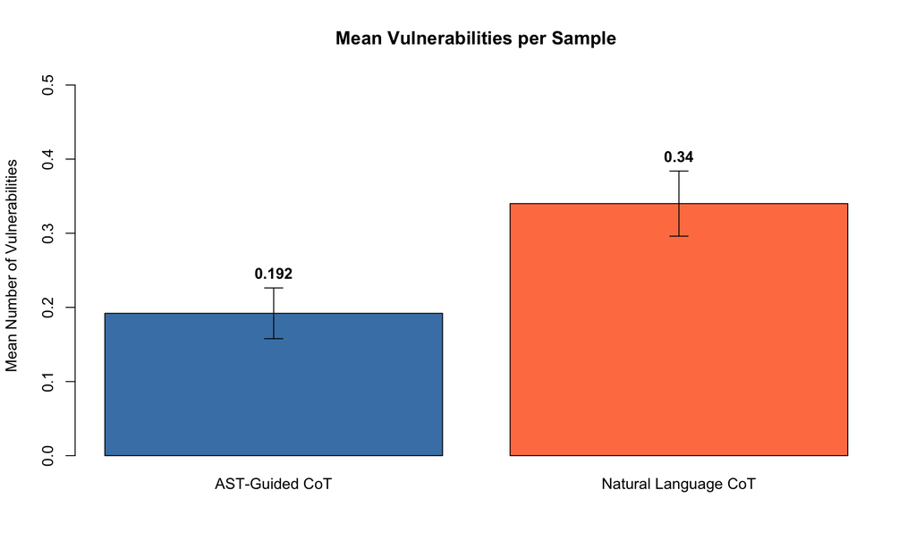

Figure 3: Mean Vulnerabilities per Sample by Prompting Method

```r
# Bar chart with error bars
means <- c(mean(ast_vulns), mean(nl_vulns))
ses <- c(sd(ast_vulns)/sqrt(length(ast_vulns)), sd(nl_vulns)/sqrt(length(nl_vulns)))
names(means) <- c("AST-Guided CoT", "Natural Language CoT")

bp <- barplot(means, col = c("steelblue", "coral"),
              main = "Mean Vulnerabilities per Sample",
              ylab = "Mean Number of Vulnerabilities",
              ylim = c(0, max(means + ses * 2) * 1.2))

# Add error bars (±1 SE)
arrows(bp, means - ses, bp, means + ses, angle = 90, code = 3, length = 0.1)

# Add mean labels
text(x = bp, y = means + ses + 0.02, labels = round(means, 3), font = 2)
```

# 5 Analysis 4: Two-Proportion Z-Test

This test directly compares the vulnerability proportions between the two prompting methods.

```r
# Get counts
ast_vuln <- sum(df$has_vulnerability[df$condition == "AST-Guided CoT"])
ast_total <- sum(df$condition == "AST-Guided CoT")
nl_vuln <- sum(df$has_vulnerability[df$condition == "Natural Language CoT"])
nl_total <- sum(df$condition == "Natural Language CoT")

# Two-proportion z-test
prop_test <- prop.test(c(ast_vuln, nl_vuln), c(ast_total, nl_total))

prop_table <- data.frame(
  `Prompting Method` = c("AST-Guided CoT", "Natural Language CoT"),
  `Vulnerable` = c(ast_vuln, nl_vuln),
  `Total` = c(ast_total, nl_total),
  `Proportion` = c(round(ast_vuln/ast_total, 3), round(nl_vuln/nl_total, 3)),
  `Percentage` = c(paste0(round(ast_vuln/ast_total * 100, 1), "%"),
                   paste0(round(nl_vuln/nl_total * 100, 1), "%"))
)

knitr::kable(prop_table,
             caption = "Table 6: Vulnerability Proportions",
             row.names = FALSE)
```

Table 6: Vulnerability Proportions

| Prompting.Method | Vulnerable | Total | Proportion | Percentage |
| --- | --- | --- | --- | --- |
| AST-Guided CoT | 31 | 250 | 0.124 | 12.4% |
| Natural Language CoT | 55 | 250 | 0.220 | 22% |

```r
z_results <- data.frame(
  Test = "Two-Proportion Z-Test",
  `p-value` = round(prop_test$p.value, 4),
  `95% Confidence Interval` = paste0("[", round(prop_test$conf.int[1], 4), ", ", round(prop_test$conf.int[2], 4), "]"),
  `Significant (α = .05)` = ifelse(prop_test$p.value < 0.05, "Yes", "No")
)

knitr::kable(z_results,
             caption = "Table 7: Two-Proportion Z-Test Results",
             row.names = FALSE)
```

Table 7: Two-Proportion Z-Test Results

| Test | p.value | X95..Confidence.Interval | Significant..α….05. |
| --- | --- | --- | --- |
| Two-Proportion Z-Test | 0.0064 | [-0.1656, -0.0264] | Yes |

# 6 Analysis 5: Effect Size

Even if results are not statistically significant, effect size tells us the practical magnitude of the difference.

```r
ast_rate <- ast_vuln / ast_total
nl_rate <- nl_vuln / nl_total

# Absolute difference
abs_diff <- nl_rate - ast_rate

# Relative difference (percent reduction)
rel_diff <- (abs_diff / nl_rate) * 100

# Risk ratio
risk_ratio <- ast_rate / nl_rate

effect_table <- data.frame(
  Measure = c(
    "AST-Guided CoT Vulnerability Rate",
    "Natural Language CoT Vulnerability Rate",
    "Absolute Difference",
    "Relative Difference",
    "Risk Ratio"
  ),
  Value = c(
    paste0(round(ast_rate * 100, 1), "%"),
    paste0(round(nl_rate * 100, 1), "%"),
    paste0(round(abs_diff * 100, 1), " percentage points"),
    paste0(round(rel_diff, 1), "% reduction with AST-Guided"),
    round(risk_ratio, 3)
  ),
  Interpretation = c(
    "",
    "",
    ifelse(abs_diff > 0, "NL CoT has higher rate", "AST-Guided has higher rate"),
    "",
    ifelse(risk_ratio < 1, "AST-Guided reduces risk", "AST-Guided increases risk")
  )
)

knitr::kable(effect_table,
             caption = "Table 8: Effect Size Measures",
             row.names = FALSE)
```

Table 8: Effect Size Measures

| Measure | Value | Interpretation |
| --- | --- | --- |
| AST-Guided CoT Vulnerability Rate | 12.4% |  |
| Natural Language CoT Vulnerability Rate | 22% |  |
| Absolute Difference | 9.6 percentage points | NL CoT has higher rate |
| Relative Difference | 43.6% reduction with AST-Guided |  |
| Risk Ratio | 0.564 | AST-Guided reduces risk |

# 7 Supplementary: Comparison by LLM Model

```r
# By model
by_model <- aggregate(has_vulnerability ~ model, data = df,
                      FUN = function(x) c(
                        Vulnerable = sum(x),
                        Total = length(x),
                        Rate = round(mean(x) * 100, 1)
                      ))
by_model <- do.call(data.frame, by_model)
names(by_model) <- c("Model", "Vulnerable Samples", "Total Samples", "Vulnerability Rate (%)")

knitr::kable(by_model,
             caption = "Table 9: Vulnerability Rate by LLM Model",
             row.names = FALSE)
```

Table 9: Vulnerability Rate by LLM Model

| Model | Vulnerable Samples | Total Samples | Vulnerability Rate (%) |
| --- | --- | --- | --- |
| Claude | 42 | 250 | 16.8 |
| GPT-4 | 44 | 250 | 17.6 |

```r
# Chi-square for model
contingency_model <- table(df$model, df$has_vulnerability)
chi_model <- chisq.test(contingency_model)

chi_model_results <- data.frame(
  Comparison = "Claude vs. GPT-4",
  `Chi-Square` = round(chi_model$statistic, 3),
  `p-value` = round(chi_model$p.value, 4),
  `Significant` = ifelse(chi_model$p.value < 0.05, "Yes", "No")
)

knitr::kable(chi_model_results,
             caption = "Table 10: Chi-Square Test - Vulnerability Rate by Model",
             row.names = FALSE)
```

Table 10: Chi-Square Test - Vulnerability Rate by Model

| Comparison | Chi.Square | p.value | Significant |
| --- | --- | --- | --- |
| Claude vs. GPT-4 | 0.014 | 0.9057 | No |

# 8 Results Summary

```r
# Calculate totals
ast_total_vulns <- sum(df$num_vulnerabilities[df$condition == "AST-Guided CoT"])
nl_total_vulns <- sum(df$num_vulnerabilities[df$condition == "Natural Language CoT"])
vuln_diff <- nl_total_vulns - ast_total_vulns

# Determine which method is better (fewer vulnerabilities)
ast_is_better <- ast_total_vulns < nl_total_vulns

if (ast_is_better) {
  better_method <- "AST-Guided CoT"
  worse_method <- "Natural Language CoT"
  reduction_count <- vuln_diff
  reduction_pct <- round((vuln_diff / nl_total_vulns) * 100, 1)
} else {
  better_method <- "Natural Language CoT"
  worse_method <- "AST-Guided CoT"
  reduction_count <- -vuln_diff
  reduction_pct <- round((-vuln_diff / ast_total_vulns) * 100, 1)
}

# Create summary table
summary_table <- data.frame(
  Metric = c(
    "Total Samples",
    "AST-Guided CoT Total Vulnerabilities",
    "Natural Language CoT Total Vulnerabilities",
    "Difference",
    "Better Performing Method",
    "AST-Guided CoT Vulnerability Rate",
    "Natural Language CoT Vulnerability Rate",
    "Chi-Square p-value",
    "T-Test p-value",
    "Statistically Significant"
  ),
  Value = c(
    as.character(nrow(df)),
    as.character(ast_total_vulns),
    as.character(nl_total_vulns),
    paste0(reduction_count, " fewer vulnerabilities with ", better_method),
    better_method,
    paste0(round(ast_rate * 100, 1), "%"),
    paste0(round(nl_rate * 100, 1), "%"),
    round(chi_test$p.value, 4),
    round(t_test$p.value, 4),
    ifelse(chi_test$p.value < 0.05, "Yes", "No")
  )
)

knitr::kable(summary_table,
             caption = "Key Findings",
             row.names = FALSE)
```

Key Findings

| Metric | Value |
| --- | --- |
| Total Samples | 500 |
| AST-Guided CoT Total Vulnerabilities | 48 |
| Natural Language CoT Total Vulnerabilities | 85 |
| Difference | 37 fewer vulnerabilities with AST-Guided CoT |
| Better Performing Method | AST-Guided CoT |
| AST-Guided CoT Vulnerability Rate | 12.4% |
| Natural Language CoT Vulnerability Rate | 22% |
| Chi-Square p-value | 0.0064 |
| T-Test p-value | 0.0081 |
| Statistically Significant | Yes |

## 8.1 Conclusion

```r
cat("**", better_method, "** produced fewer total vulnerabilities (**",
    min(ast_total_vulns, nl_total_vulns), "**) compared to **",
    max(ast_total_vulns, nl_total_vulns), "** for ", worse_method, ".\n\n", sep = "")
```

**AST-Guided CoT** produced fewer total vulnerabilities (**48**) compared to **85** for Natural Language CoT.

```r
cat("This represents **", reduction_count, " fewer vulnerabilities** (",
    reduction_pct, "% reduction) when using ", better_method, ".\n\n", sep = "")
```

This represents **37 fewer vulnerabilities** (43.5% reduction) when using AST-Guided CoT.

```r
if (chi_test$p.value < 0.05) {
  cat("This difference **is statistically significant** (Chi-Square p = ", round(chi_test$p.value, 4),
      ", T-Test p = ", round(t_test$p.value, 4),
      "), indicating that ", better_method, " reliably produces more secure code.\n", sep = "")
} else {
  cat("However, this difference **is not statistically significant** (Chi-Square p = ", round(chi_test$p.value, 4),
      ", T-Test p = ", round(t_test$p.value, 4),
      "), meaning the observed difference could be due to random chance rather than a true effect of the prompting method.\n", sep = "")
}
```

This difference **is statistically significant** (Chi-Square p = 0.0064, T-Test p = 0.0081), indicating that AST-Guided CoT reliably produces more secure code.